# Mental Health attendances in urgent and emergency care settings

##### Geographical variation

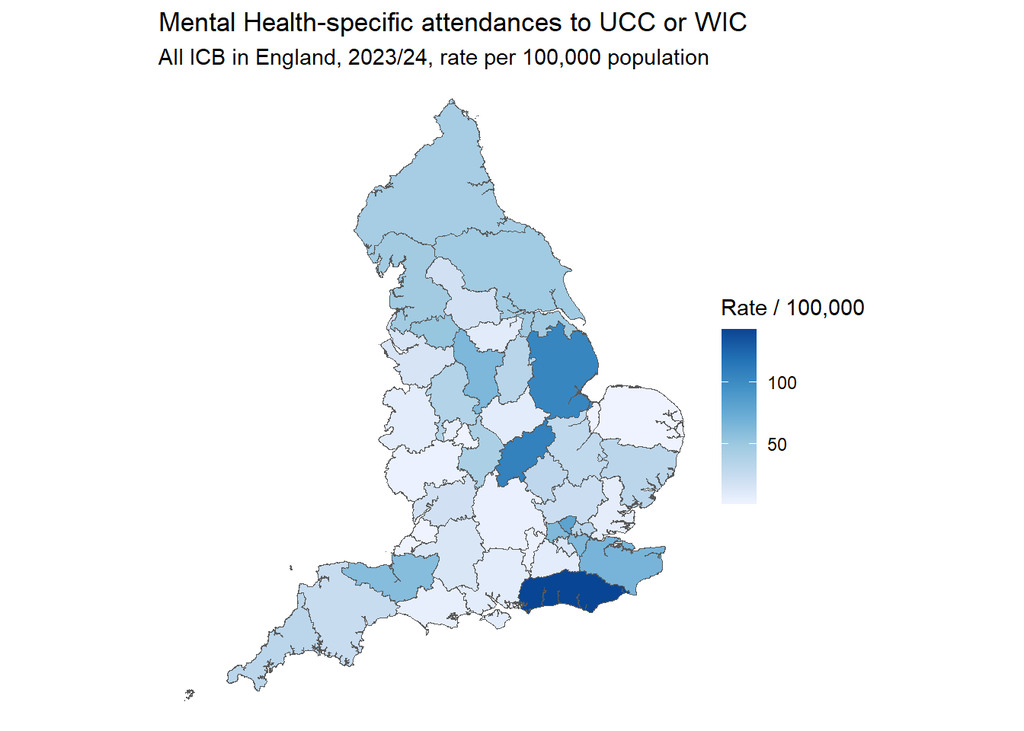

**Gender variation**

**Chart**

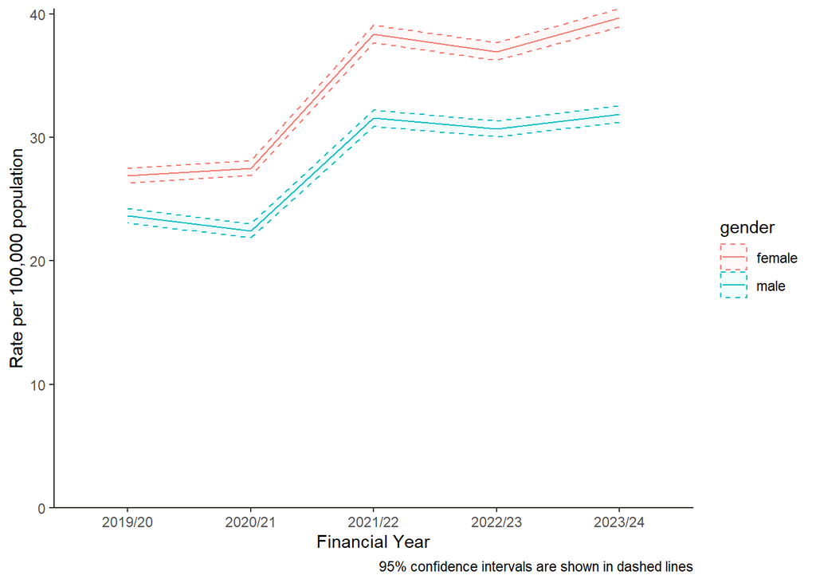

Figure 19: Rates per 100,000 population of the number of Mental Health UEC attendances by gender.

**Table**

| der_financial_year | gender | attends | count | value | lowercl | uppercl |
| --- | --- | --- | --- | --- | --- | --- |
| 2019/20 | female | 7660 | 28459130 | 26.92 | 26.32 | 27.53 |
| 2020/21 | female | 7859 | 28567320 | 27.51 | 26.91 | 28.13 |
| 2021/22 | female | 11083 | 28871204 | 38.39 | 37.68 | 39.11 |
| 2022/23 | female | 10768 | 29123108 | 36.97 | 36.28 | 37.68 |
| 2023/24 | female | 11566 | 29123108 | 39.71 | 38.99 | 40.44 |
| 2019/20 | male | 6586 | 27827831 | 23.67 | 23.1 | 24.25 |
| 2020/21 | male | 6280 | 27982818 | 22.44 | 21.89 | 23 |
| 2021/22 | male | 8741 | 27683687 | 31.57 | 30.92 | 32.24 |
| 2022/23 | male | 8587 | 27983290 | 30.69 | 30.04 | 31.34 |
| 2023/24 | male | 8927 | 27983290 | 31.9 | 31.24 | 32.57 |

**Age-group variation**

**Chart**

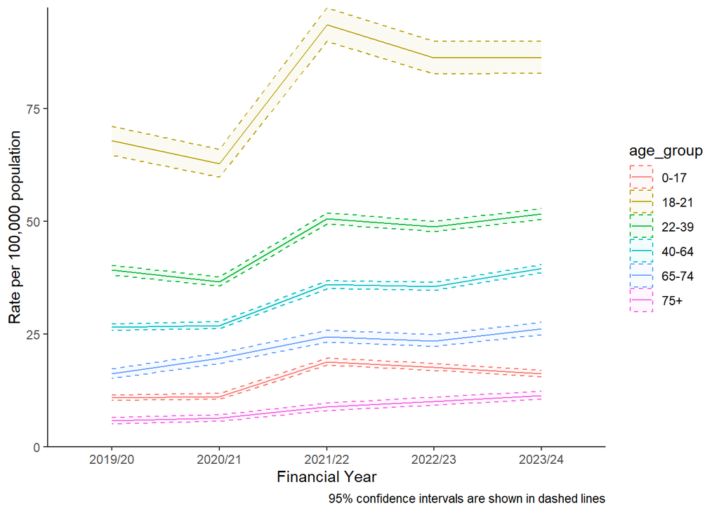

Figure 20: Rates per 100,000 population of the number of Mental Health UEC attendances by age group.

**Table**

| der_financial_year | age_group | attends | count | value | lowercl | uppercl |
| --- | --- | --- | --- | --- | --- | --- |
| 2019/20 | 0-17 | 1309 | 12023568 | 10.89 | 10.31 | 11.49 |
| 2020/21 | 0-17 | 1352 | 12093288 | 11.18 | 10.59 | 11.79 |
| 2021/22 | 0-17 | 2222 | 11762878 | 18.89 | 18.11 | 19.69 |
| 2022/23 | 0-17 | 2102 | 11886906 | 17.68 | 16.94 | 18.46 |
| 2023/24 | 0-17 | 1931 | 11886906 | 16.24 | 15.53 | 16.99 |
| 2019/20 | 18-21 | 1769 | 2606458 | 67.87 | 64.74 | 71.11 |
| 2020/21 | 18-21 | 1615 | 2569709 | 62.85 | 59.82 | 65.99 |
| 2021/22 | 18-21 | 2435 | 2600225 | 93.65 | 89.96 | 97.44 |
| 2022/23 | 18-21 | 2283 | 2645130 | 86.31 | 82.81 | 89.92 |
| 2023/24 | 18-21 | 2284 | 2645130 | 86.35 | 82.84 | 89.96 |

[output cut: 20 more lines]

**Ethnic group variation**

**Chart**

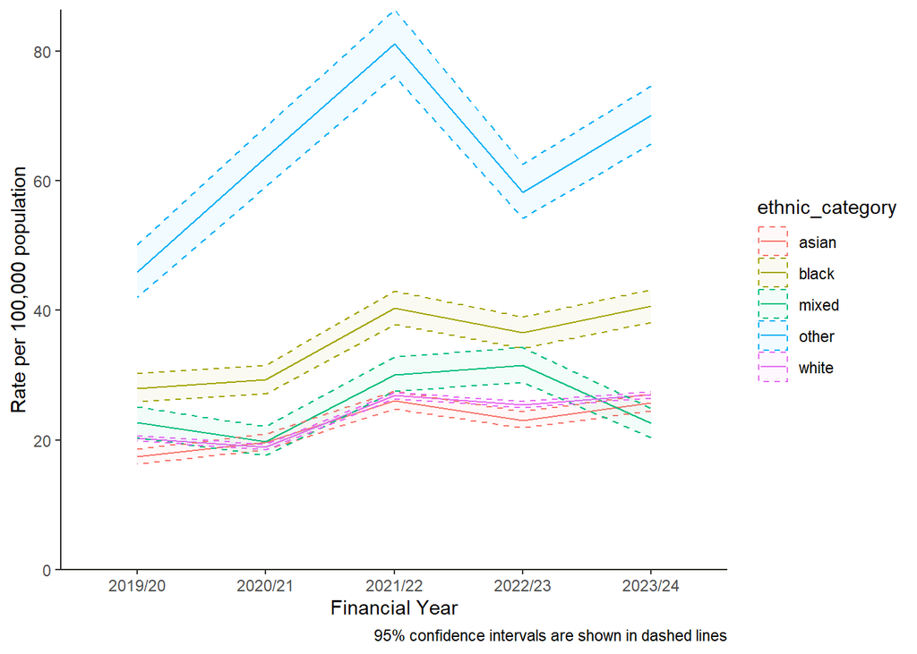

Figure 21: Rates per 100,000 population of the number of Mental Health UEC attendances by ethnic category.

**Table**

| der_financial_year | ethnic_category | attends | count | value | lowercl | uppercl |
| --- | --- | --- | --- | --- | --- | --- |
| 2019/20 | asian | 899 | 5169879 | 17.39 | 16.27 | 18.56 |
| 2020/21 | asian | 1040 | 5298188.5 | 19.63 | 18.45 | 20.86 |
| 2021/22 | asian | 1416 | 5426498 | 26.09 | 24.75 | 27.49 |
| 2022/23 | asian | 1281 | 5554807.5 | 23.06 | 21.82 | 24.36 |
| 2023/24 | asian | 1465 | 5683117 | 25.78 | 24.47 | 27.13 |
| 2019/20 | black | 636 | 2274658.8 | 27.96 | 25.83 | 30.22 |
| 2020/21 | black | 682 | 2328164.4 | 29.29 | 27.14 | 31.58 |
| 2021/22 | black | 961 | 2381670 | 40.35 | 37.84 | 42.98 |
| 2022/23 | black | 890 | 2435175.6 | 36.55 | 34.19 | 39.03 |
| 2023/24 | black | 1012 | 2488681.2 | 40.66 | 38.2 | 43.25 |

[output cut: 15 more lines]

**Socioeconomic variation**

**Chart1**

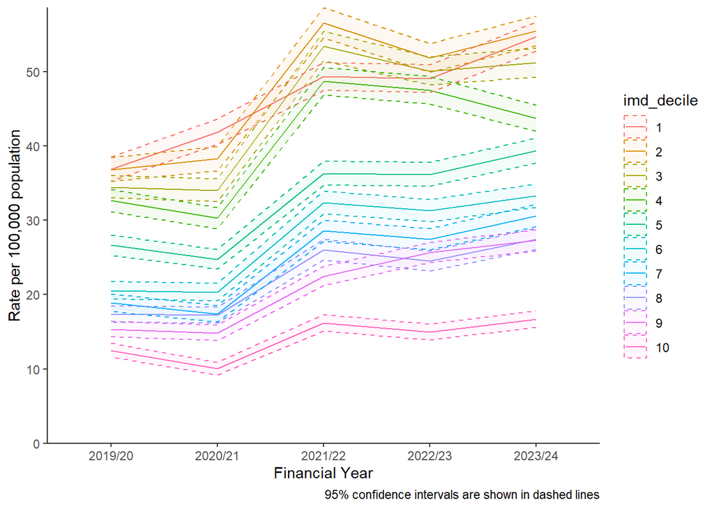

Figure 22: Rates per 100,000 population of the number of Mental Health UEC attendances by Index of Multiple Deprivation decile.

**Chart2**

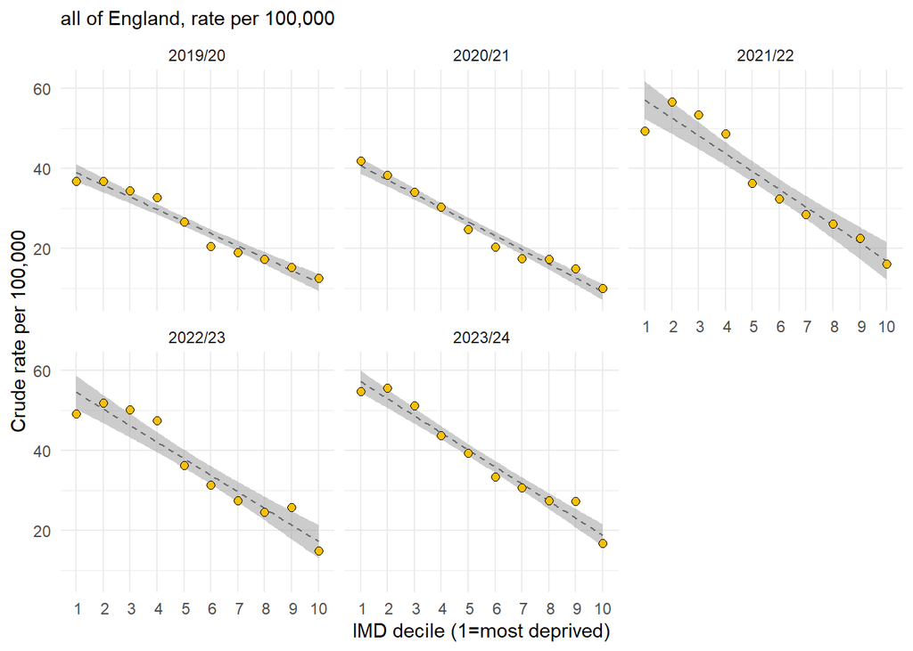

**Table**

| der_financial_year | imd_decile | attends | count | value | lowercl | uppercl |
| --- | --- | --- | --- | --- | --- | --- |
| 2019/20 | 1 | 2059 | 5588091 | 36.85 | 35.27 | 38.47 |
| 2020/21 | 1 | 2347 | 5603911 | 41.88 | 40.2 | 43.61 |
| 2021/22 | 1 | 2661 | 5394735 | 49.33 | 47.47 | 51.24 |
| 2022/23 | 1 | 2674 | 5453738 | 49.03 | 47.19 | 50.92 |
| 2023/24 | 1 | 2983 | 5453738 | 54.7 | 52.75 | 56.7 |
| 2019/20 | 2 | 2090 | 5677439 | 36.81 | 35.25 | 38.43 |
| 2020/21 | 2 | 2180 | 5697232 | 38.26 | 36.67 | 39.9 |
| 2021/22 | 2 | 3068 | 5422810 | 56.58 | 54.59 | 58.61 |
| 2022/23 | 2 | 2831 | 5463929 | 51.81 | 49.92 | 53.76 |
| 2023/24 | 2 | 3031 | 5463929 | 55.47 | 53.52 | 57.48 |

[output cut: 40 more lines]

**Rural-urban variation**

**Chart**

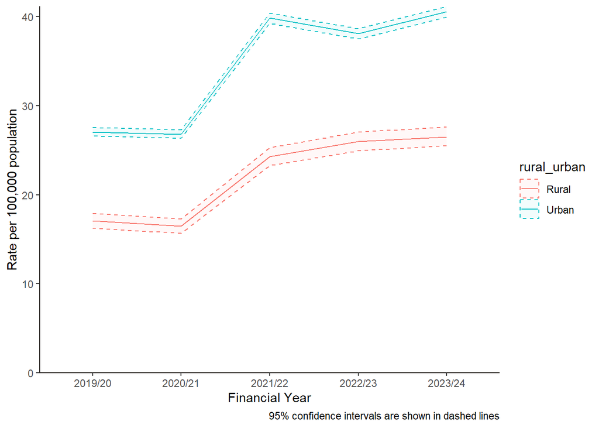

**Table**

| der_financial_year | rural_urban | attends | count | value | lowercl | uppercl |
| --- | --- | --- | --- | --- | --- | --- |
| 2019/20 | Rural | 1639 | 9608249 | 17.06 | 16.24 | 17.9 |
| 2020/21 | Rural | 1595 | 9683314 | 16.47 | 15.67 | 17.3 |
| 2021/22 | Rural | 2234 | 9201537 | 24.28 | 23.28 | 25.31 |
| 2022/23 | Rural | 2410 | 9279480 | 25.97 | 24.94 | 27.03 |
| 2023/24 | Rural | 2460 | 9279480 | 26.51 | 25.47 | 27.58 |
| 2019/20 | Urban | 12630 | 46678712 | 27.06 | 26.59 | 27.53 |
| 2020/21 | Urban | 12561 | 46866824 | 26.8 | 26.33 | 27.27 |
| 2021/22 | Urban | 17617 | 44203614 | 39.85 | 39.27 | 40.45 |
| 2022/23 | Urban | 16965 | 44525824 | 38.1 | 37.53 | 38.68 |
| 2023/24 | Urban | 18066 | 44525824 | 40.57 | 39.98 | 41.17 |

Figure 23: Rates per 100,000 population of the number of Mental Health UEC attendances by rural and urban populations.

#### Percentage of MH UEC attendances known to specialist services

**Overview**

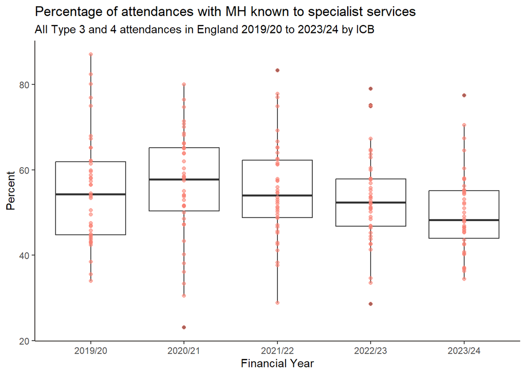

Figure 24: Percentage of Mental Health UEC attendances known to specialist services over time.

**ICB Variation**

| ICB | 2019/20 | 2020/21 | 2021/22 | 2022/23 | 2023/24 |
| --- | --- | --- | --- | --- | --- |
| NHS Sussex Integrated Care Board | 82.35 | 74.66 | 77.82 | 74.86 | 77.46 |
| NHS Dorset Integrated Care Board | 61.48 | 52.94 | 66.67 | 53.66 | 70.45 |
| NHS Cambridgeshire and Peterborough Integrated Care Board | 53.72 | 48.51 | 77 | 79.02 | 67.42 |
| NHS Herefordshire and Worcestershire Integrated Care Board | 75 | 70 | 69.23 | 53.33 | 64.52 |
| NHS Lincolnshire Integrated Care Board | 59.6 | 63.95 | 62.6 | 67.28 | 60.37 |
| NHS Surrey Heartlands Integrated Care Board | 67.96 | 68.54 | 61.67 | 55.75 | 58.06 |
| NHS Norfolk and Waveney Integrated Care Board | 57.3 | 65 | 83.33 | 64.71 | 57.89 |
| NHS Lancashire and South Cumbria Integrated Care Board | 62.09 | 58.47 | 52.59 | 53.67 | 57.74 |
| NHS South East London Integrated Care Board | 80.13 | 80.03 | 65.21 | 57.67 | 56.21 |
| NHS Greater Manchester Integrated Care Board | 62.17 | 65.11 | 61.29 | 55.24 | 55.31 |

[output cut: 32 more lines]

Breakdowns for the number of UEC attendances with MH as primary reason/diagnosis where the patient was known to specialist services are below.

**Gender variation**

**Chart**

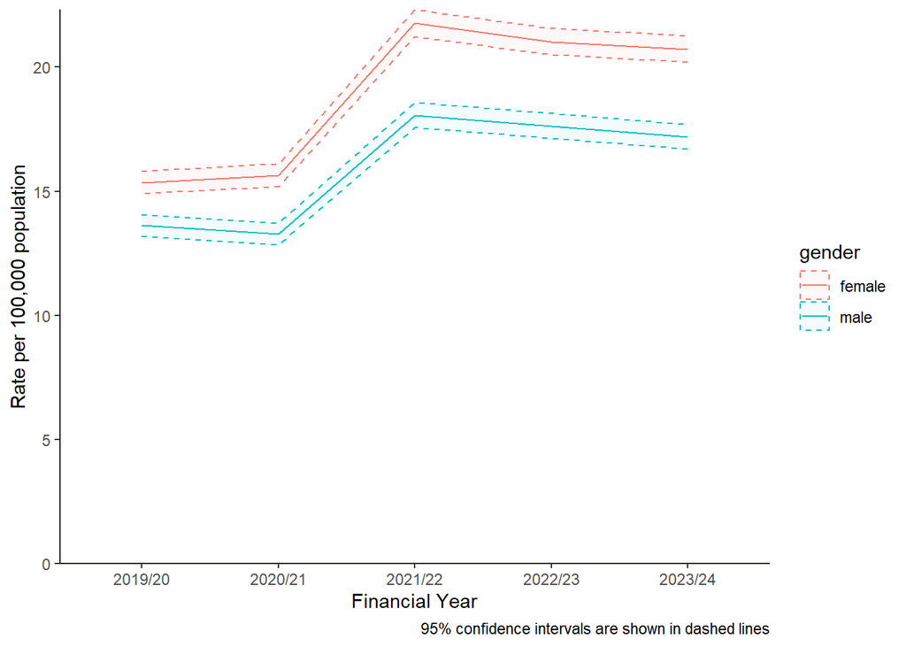

Figure 25: Rates per 100,000 population of the number of Mental Health UEC attendances where the patient was known to specialist services by gender.

**Table**

| der_financial_year | gender | attends | count | value | lowercl | uppercl |
| --- | --- | --- | --- | --- | --- | --- |
| 2019/20 | female | 4368 | 28459130 | 15.35 | 14.9 | 15.81 |
| 2020/21 | female | 4464 | 28567320 | 15.63 | 15.17 | 16.09 |
| 2021/22 | female | 6286 | 28871204 | 21.77 | 21.24 | 22.32 |
| 2022/23 | female | 6121 | 29123108 | 21.02 | 20.49 | 21.55 |
| 2023/24 | female | 6034 | 29123108 | 20.72 | 20.2 | 21.25 |
| 2019/20 | male | 3790 | 27827831 | 13.62 | 13.19 | 14.06 |
| 2020/21 | male | 3714 | 27982818 | 13.27 | 12.85 | 13.71 |
| 2021/22 | male | 4999 | 27683687 | 18.06 | 17.56 | 18.57 |
| 2022/23 | male | 4934 | 27983290 | 17.63 | 17.14 | 18.13 |
| 2023/24 | male | 4807 | 27983290 | 17.18 | 16.7 | 17.67 |

**Age-group variation**

**Chart**

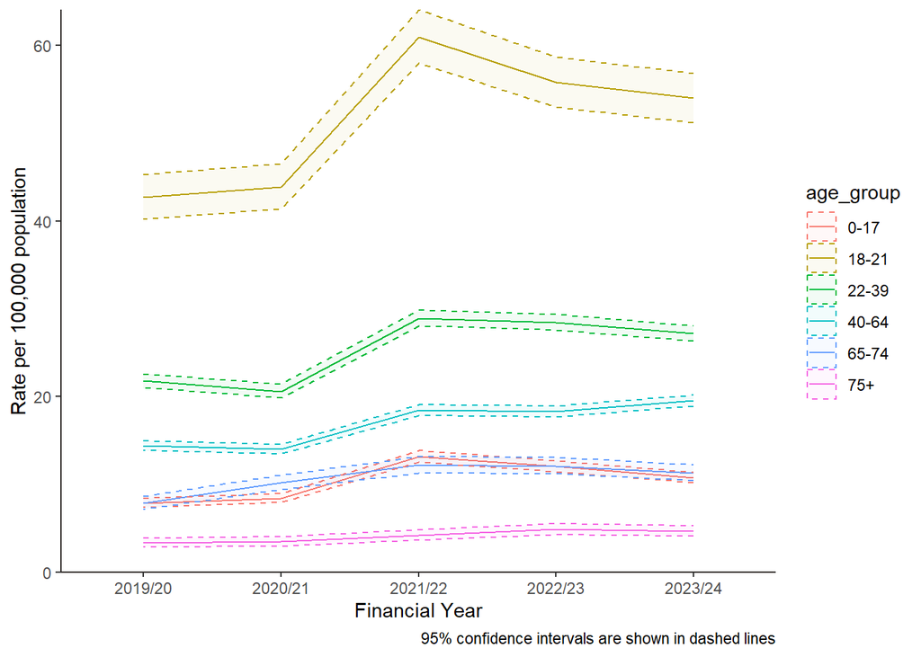

Figure 26: Rates per 100,000 population of the number of Mental Health UEC attendances where the patient was known to specialist services by age group.

**Table**

| der_financial_year | age_group | attends | count | value | lowercl | uppercl |
| --- | --- | --- | --- | --- | --- | --- |
| 2019/20 | 0-17 | 945 | 12023568 | 7.86 | 7.37 | 8.38 |
| 2020/21 | 0-17 | 1019 | 12093288 | 8.43 | 7.92 | 8.96 |
| 2021/22 | 0-17 | 1550 | 11762878 | 13.18 | 12.53 | 13.85 |
| 2022/23 | 0-17 | 1436 | 11886906 | 12.08 | 11.46 | 12.72 |
| 2023/24 | 0-17 | 1277 | 11886906 | 10.74 | 10.16 | 11.35 |
| 2019/20 | 18-21 | 1113 | 2606458 | 42.7 | 40.23 | 45.29 |
| 2020/21 | 18-21 | 1128 | 2569709 | 43.9 | 41.37 | 46.53 |
| 2021/22 | 18-21 | 1586 | 2600225 | 60.99 | 58.03 | 64.07 |
| 2022/23 | 18-21 | 1476 | 2645130 | 55.8 | 52.99 | 58.72 |
| 2023/24 | 18-21 | 1428 | 2645130 | 53.99 | 51.22 | 56.86 |

[output cut: 20 more lines]

**Ethnic group variation**

**Chart**

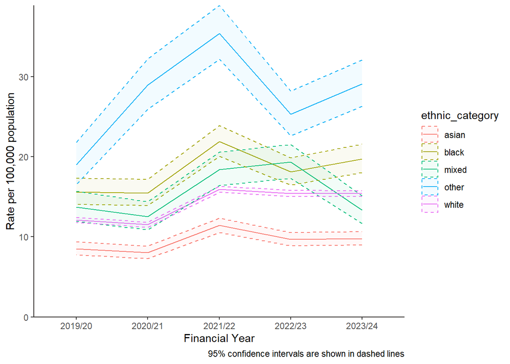

Figure 27: Rates per 100,000 population of the number of Mental Health UEC attendances where the patient was known to specialist services by ethnic category.

**Table**

| der_financial_year | ethnic_category | attends | count | value | lowercl | uppercl |
| --- | --- | --- | --- | --- | --- | --- |
| 2019/20 | asian | 441 | 5169879 | 8.53 | 7.75 | 9.36 |
| 2020/21 | asian | 426 | 5298188.5 | 8.04 | 7.29 | 8.84 |
| 2021/22 | asian | 620 | 5426498 | 11.43 | 10.54 | 12.36 |
| 2022/23 | asian | 538 | 5554807.5 | 9.69 | 8.88 | 10.54 |
| 2023/24 | asian | 556 | 5683117 | 9.78 | 8.99 | 10.63 |
| 2019/20 | black | 355 | 2274658.8 | 15.61 | 14.03 | 17.32 |
| 2020/21 | black | 360 | 2328164.4 | 15.46 | 13.91 | 17.15 |
| 2021/22 | black | 522 | 2381670 | 21.92 | 20.08 | 23.88 |
| 2022/23 | black | 441 | 2435175.6 | 18.11 | 16.46 | 19.88 |
| 2023/24 | black | 491 | 2488681.2 | 19.73 | 18.02 | 21.55 |

[output cut: 15 more lines]

**Socioeconomic variation**

**Chart**

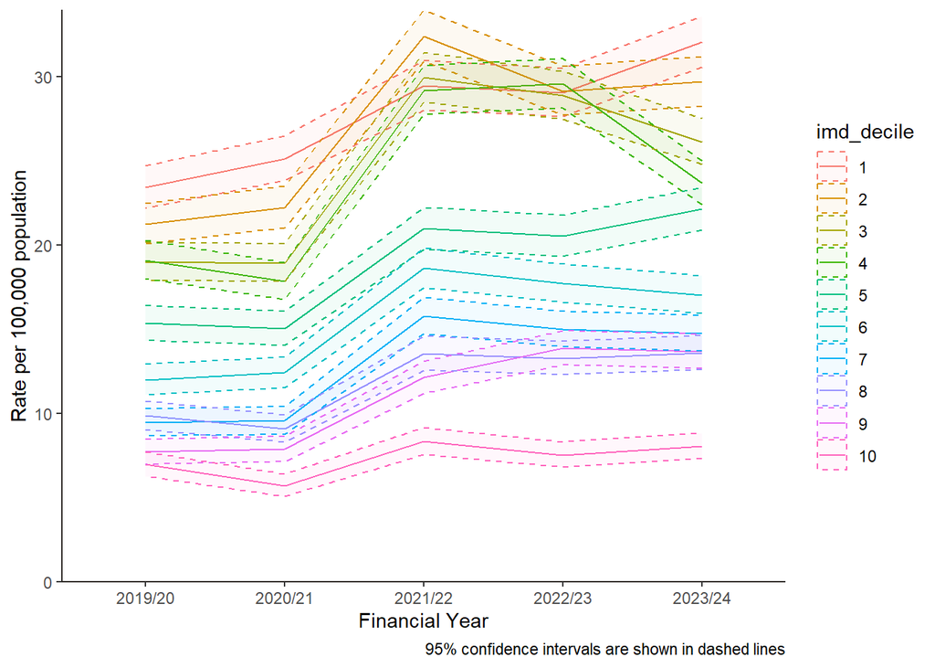

Figure 28: Rates per 100,000 population of the number of Mental Health UEC attendances where the patient was known to specialist services by Index of Multiple Deprivation decile.

**Table**

| der_financial_year | imd_decile | attends | count | value | lowercl | uppercl |
| --- | --- | --- | --- | --- | --- | --- |
| 2019/20 | 1 | 1309 | 5588091 | 23.42 | 22.17 | 24.73 |
| 2020/21 | 1 | 1409 | 5603911 | 25.14 | 23.85 | 26.49 |
| 2021/22 | 1 | 1589 | 5394735 | 29.45 | 28.02 | 30.94 |
| 2022/23 | 1 | 1584 | 5453738 | 29.04 | 27.63 | 30.51 |
| 2023/24 | 1 | 1749 | 5453738 | 32.07 | 30.58 | 33.61 |
| 2019/20 | 2 | 1207 | 5677439 | 21.26 | 20.08 | 22.49 |
| 2020/21 | 2 | 1267 | 5697232 | 22.24 | 21.03 | 23.5 |
| 2021/22 | 2 | 1758 | 5422810 | 32.42 | 30.92 | 33.97 |
| 2022/23 | 2 | 1593 | 5463929 | 29.15 | 27.74 | 30.62 |
| 2023/24 | 2 | 1623 | 5463929 | 29.7 | 28.28 | 31.19 |

[output cut: 40 more lines]

**Rural-urban variation**

**Chart**

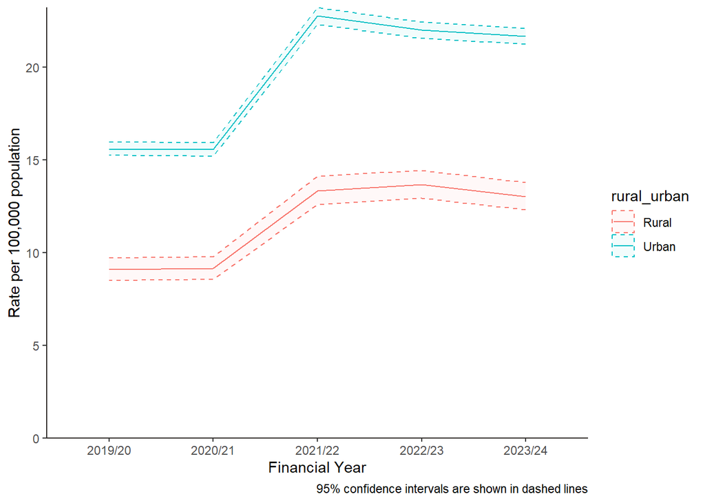

Figure 29: Rates per 100,000 population of the number of Mental Health UEC attendances where the patient was known to specialist services by rural and urban populations.

**Table**

| der_financial_year | rural_urban | attends | count | value | lowercl | uppercl |
| --- | --- | --- | --- | --- | --- | --- |
| 2019/20 | Rural | 873 | 9608249 | 9.09 | 8.49 | 9.71 |
| 2020/21 | Rural | 885 | 9683314 | 9.14 | 8.55 | 9.76 |
| 2021/22 | Rural | 1228 | 9201537 | 13.35 | 12.61 | 14.11 |
| 2022/23 | Rural | 1269 | 9279480 | 13.68 | 12.93 | 14.45 |
| 2023/24 | Rural | 1209 | 9279480 | 13.03 | 12.3 | 13.78 |
| 2019/20 | Urban | 7287 | 46678712 | 15.61 | 15.25 | 15.97 |
| 2020/21 | Urban | 7295 | 46866824 | 15.57 | 15.21 | 15.93 |
| 2021/22 | Urban | 10068 | 44203614 | 22.78 | 22.33 | 23.23 |
| 2022/23 | Urban | 9798 | 44525824 | 22.01 | 21.57 | 22.45 |
| 2023/24 | Urban | 9650 | 44525824 | 21.67 | 21.24 | 22.11 |

## NHS 111 calls

Callers to the NHS 111 service would be typically those unable to reach primary care services or to find out information and the appropriate treatment setting for a non-urgent health complaint.

The average cost of a call to NHS 111 is around £12 with those requiring clinical call-back an extra £15 and hear-treat or see-treat ambulance (999 referrals) costing on average another £203 https://www.ncbi.nlm.nih.gov/books/NBK575169/.

### Detailed breakdowns

#### % of all calls being MH-related

**Overview**

[figure not shown]

Figure 30: Percentage of Mental Health calls over time.

**ICB Variation**

| ICB | 2017/18 | 2018/19 | 2019/20 | 2020/21 | 2021/22 |
| --- | --- | --- | --- | --- | --- |
| NHS Northamptonshire Integrated Care Board | 0.07 | 0.07 | 1.45 | 1.79 | 1.46 |
| NHS Leicester Leicestershire and Rutland Integrated Care Board | 0.05 | 0.05 | 1.4 | 1.72 | 1.4 |
| NHS Derby and Derbyshire Integrated Care Board | 0.05 | 0.06 | 1.5 | 1.6 | 1.36 |
| NHS Hampshire and Isle of Wight Integrated Care Board | 1.22 | 1.34 | 1.71 | 1.87 | 1.25 |
| NHS Nottingham and Nottinghamshire Integrated Care Board | 0.15 | 0.13 | 1.5 | 1.44 | 1.22 |
| NHS Lincolnshire Integrated Care Board | 0.06 | 0.08 | 1.43 | 1.35 | 1.2 |
| NHS Norfolk and Waveney Integrated Care Board | 1.91 | 1.63 | 1.48 | 1.4 | 1.18 |
| NHS South Yorkshire Integrated Care Board | 1.51 | 1.62 | 1.61 | 1.6 | 1.16 |
| NHS Humber and North Yorkshire Integrated Care Board | 1.4 | 1.29 | 1.33 | 1.48 | 1.15 |
| NHS West Yorkshire Integrated Care Board | 1.31 | 1.35 | 1.4 | 1.52 | 1.14 |

[output cut: 30 more lines]

**Gender variation**

**Chart**

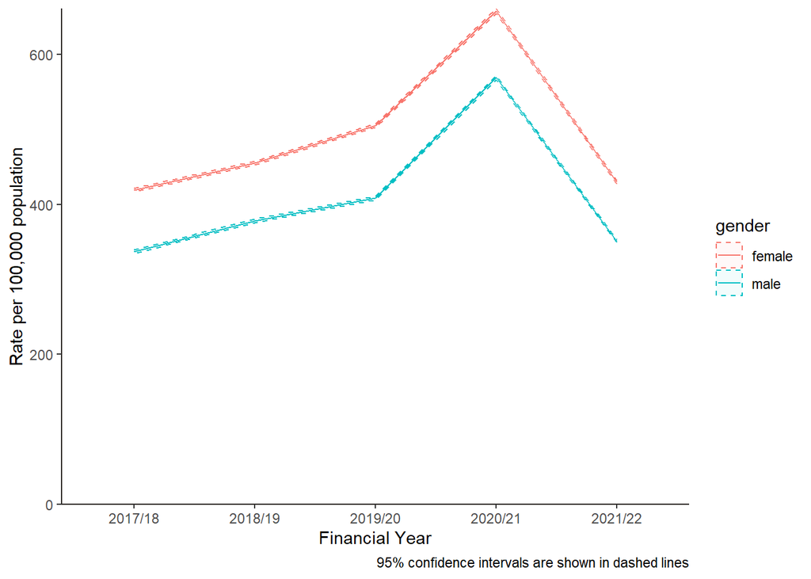

Figure 31: Rates per 100,000 population of the number of Mental Health related calls to NHS111 by gender.

**Table**

| der_financial_year | gender | calls | count | value | lowercl | uppercl |
| --- | --- | --- | --- | --- | --- | --- |
| 2017/18 | female | 118056 | 28138377 | 419.56 | 417.17 | 421.96 |
| 2018/19 | female | 128938 | 28309236 | 455.46 | 452.98 | 457.96 |
| 2019/20 | female | 143817 | 28459130 | 505.35 | 502.74 | 507.96 |
| 2020/21 | female | 188115 | 28567320 | 658.5 | 655.52 | 661.48 |
| 2021/22 | female | 124165 | 28871204 | 430.07 | 427.68 | 432.46 |
| 2017/18 | male | 92612 | 27481053 | 337 | 334.84 | 339.18 |
| 2018/19 | male | 104701 | 27667942 | 378.42 | 376.13 | 380.72 |
| 2019/20 | male | 113716 | 27827831 | 408.64 | 406.27 | 411.02 |
| 2020/21 | male | 159422 | 27982818 | 569.71 | 566.92 | 572.52 |
| 2021/22 | male | 97208 | 27683687 | 351.14 | 348.93 | 353.35 |

**Age-group variation**

**Chart**

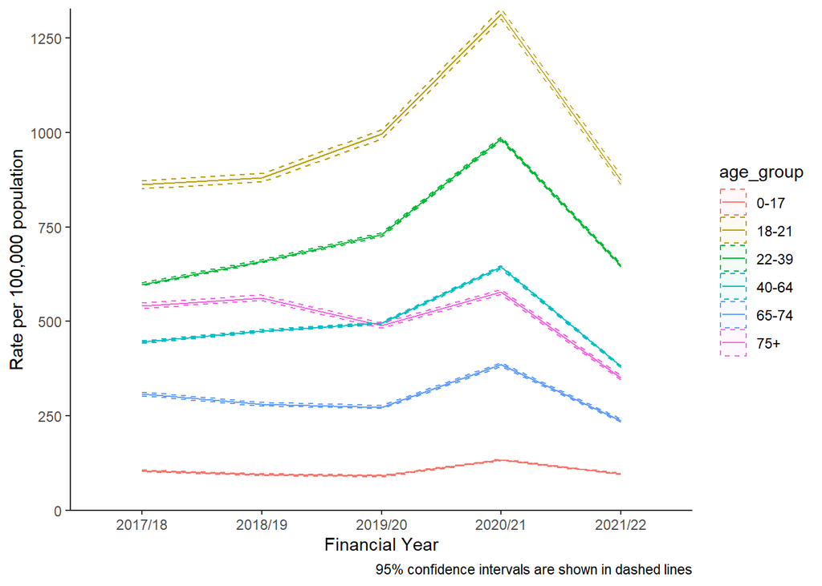

Figure 32: Rates per 100,000 population of the number of Mental Health related calls to NHS111 by age group.

**Table**

| der_financial_year | age_group | calls | count | value | lowercl | uppercl |
| --- | --- | --- | --- | --- | --- | --- |
| 2017/18 | 0-17 | 12339 | 11866957 | 103.98 | 102.15 | 105.83 |
| 2018/19 | 0-17 | 11267 | 11954618 | 94.25 | 92.52 | 96 |
| 2019/20 | 0-17 | 10945 | 12023568 | 91.03 | 89.33 | 92.75 |
| 2020/21 | 0-17 | 16175 | 12093288 | 133.75 | 131.7 | 135.83 |
| 2021/22 | 0-17 | 11344 | 11762878 | 96.44 | 94.67 | 98.23 |
| 2017/18 | 18-21 | 23048 | 2674874 | 861.65 | 850.56 | 872.85 |
| 2018/19 | 18-21 | 23351 | 2650753 | 880.92 | 869.66 | 892.29 |
| 2019/20 | 18-21 | 25967 | 2606458 | 996.26 | 984.18 | 1008.45 |
| 2020/21 | 18-21 | 33752 | 2569709 | 1313.46 | 1299.48 | 1327.54 |
| 2021/22 | 18-21 | 22738 | 2600225 | 874.46 | 863.13 | 885.9 |

[output cut: 20 more lines]

**Socioeconomic variation**

**Chart1**

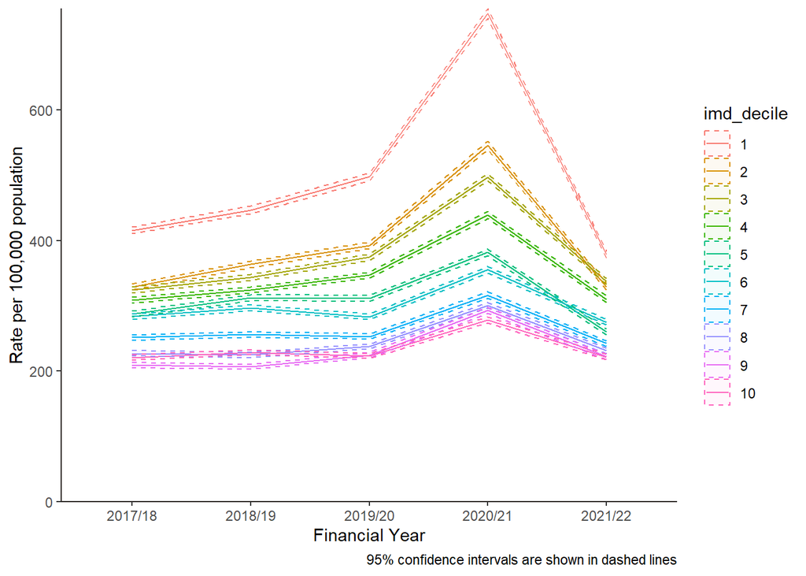

Figure 33: Rates per 100,000 population of the number of Mental Health related calls to NHS111 by Index of Multiple Deprivation decile.

**Table**

| der_financial_year | imd_decile | calls | count | value | lowercl | uppercl |
| --- | --- | --- | --- | --- | --- | --- |
| 2017/18 | 1 | 22916 | 5512413 | 415.72 | 410.35 | 421.13 |
| 2018/19 | 1 | 24823 | 5553968 | 446.94 | 441.4 | 452.54 |
| 2019/20 | 1 | 27811 | 5588091 | 497.68 | 491.85 | 503.57 |
| 2020/21 | 1 | 41919 | 5603911 | 748.03 | 740.89 | 755.23 |
| 2021/22 | 1 | 20403 | 5394735 | 378.2 | 373.03 | 383.43 |
| 2017/18 | 2 | 18468 | 5619674 | 328.63 | 323.91 | 333.41 |
| 2018/19 | 2 | 20556 | 5653651 | 363.59 | 358.63 | 368.59 |
| 2019/20 | 2 | 22282 | 5677439 | 392.47 | 387.33 | 397.65 |
| 2020/21 | 2 | 31089 | 5697232 | 545.69 | 539.64 | 551.79 |
| 2021/22 | 2 | 17857 | 5422810 | 329.29 | 324.48 | 334.16 |

[output cut: 40 more lines]

**Rural-urban variation**

**Chart**

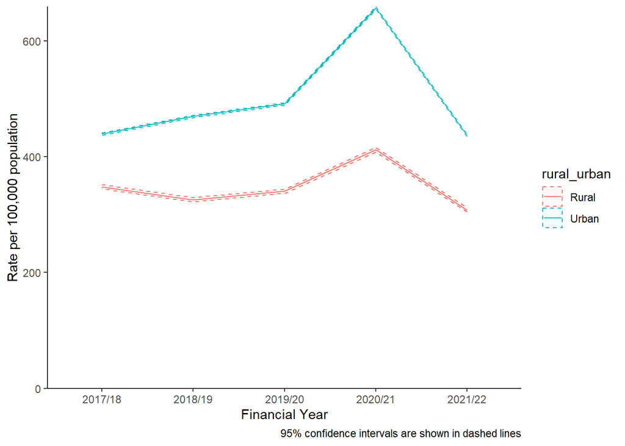

Figure 34: Rates per 100,000 population of the number of Mental Health related calls to NHS111 by rural and urban populations.

**Table**

| der_financial_year | rural_urban | calls | count | value | lowercl | uppercl |
| --- | --- | --- | --- | --- | --- | --- |
| 2017/18 | Rural | 32935 | 9458096 | 348.22 | 344.47 | 352 |
| 2018/19 | Rural | 31031 | 9529682 | 325.62 | 322.01 | 329.27 |
| 2019/20 | Rural | 32718 | 9608249 | 340.52 | 336.84 | 344.23 |
| 2020/21 | Rural | 39917 | 9683314 | 412.22 | 408.19 | 416.29 |
| 2021/22 | Rural | 28351 | 9201537 | 308.11 | 304.54 | 311.72 |
| 2017/18 | Urban | 202755 | 46161334 | 439.23 | 437.32 | 441.15 |
| 2018/19 | Urban | 218214 | 46447496 | 469.81 | 467.84 | 471.78 |
| 2019/20 | Urban | 229421 | 46678712 | 491.49 | 489.48 | 493.5 |
| 2020/21 | Urban | 307796 | 46866824 | 656.75 | 654.43 | 659.07 |
| 2021/22 | Urban | 193131 | 44203614 | 436.91 | 434.97 | 438.87 |